# Predicting Fitness Classification from Health & Lifestyle Metrics

Sophia Qiu

Spring 2026

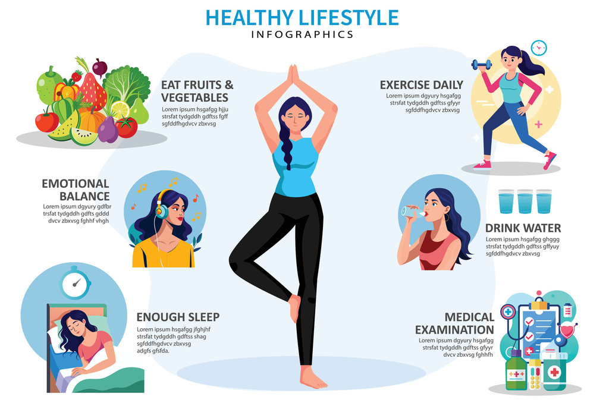

# Introduction

We’re living in an era where our wearables and health apps constantly bombard us with personal data. But all this information made me wonder: can we reliably tell if someone is physically fit just by looking at their basic health numbers and daily habits? To explore this, I am using a synthetic dataset of health, physiological, and lifestyle measurements. Since this data is artificially generated, it works perfectly for testing out machine learning models in the scope of this project, but we always have to keep in mind that real-world human health is vastly more complex and unpredictable.

While “fitness” is a highly nuanced and multidimensional concept in reality, I am keeping things simple here by operationalizing it as a binary yes-or-no question. The goal is to see if we can categorize people into either “fit” or “not fit” groups based on their observable traits. To make these predictions, I am using physiological measurements like resting heart rate, blood pressure, height, and weight, alongside behavioral factors like sleep duration, nutrition quality, physical activity index, smoking status, and gender.

Because we are sorting individuals into one of two distinct groups, this is a classic **binary classification** problem. To tackle it, I will be evaluating a wide variety of machine learning algorithms to see which one learns the underlying patterns best. The lineup of models includes logistic regression, linear and quadratic discriminant analysis, elastic net penalized regression, pruned decision trees, random forests, and gradient-boosted trees. Ultimately, I will crown the winning model based on its cross-validated ROC AUC score, which essentially tells us how well the algorithm consistently separates the fit individuals from the rest.

## Data Citation

The dataset used in this project is the **Fitness Classification Dataset (Synthetic)**, created by Mohammed Darrige and published on Kaggle. It contains 2,000 synthetically generated observations with 10 predictive features and one binary outcome variable (`is_fit`). Because the data are synthetic, they are free of privacy concerns and are suitable for educational use.

- **Title:** Fitness Classification Dataset (Synthetic)
- **Author:** Mohammed Darrige (Kaggle username: muhammedderric)
- **Source:** Kaggle
- **Link:** https://www.kaggle.com/datasets/muhammedderric/fitness-classification-dataset-synthetic

## Project Outline

To build our final classification model, we will follow a structured workflow. First, we load and clean the data—handling missing values and standardizing the mixed-type `smokes` column. Next, we conduct exploratory data analysis to visualize distributions, relationships, and class balance. We then split the data into training (80%) and testing (20%) sets using stratified sampling on `is_fit`, define a preprocessing recipe, and set up cross-validation. Seven model types are fit and tuned: logistic regression, LDA, QDA, elastic net, a pruned decision tree, random forest, and a gradient-boosted tree. The best model is then evaluated on the held-out test set, and conclusions are drawn.

# Exploring Our Data

## Loading Libraries and Data

We begin by loading the necessary packages and reading in the dataset.

```r
data <- read.csv("C:\\Users\\qiuso\\OneDrive\\131\\data\\fitness_dataset.csv")
dim(data)
```

```
## [1] 2000   11
```

The dataset contains 2000 rows and 11 columns. Let’s take a quick look at the first few rows to understand the raw data structure.

```r
data %>%
  head(10) %>%
  kable(caption = "First 10 rows of the raw fitness dataset") %>%
  kable_styling(bootstrap_options = c("striped", "hover", "condensed"), full_width = FALSE)
```

First 10 rows of the raw fitness dataset

| age | height_cm | weight_kg | heart_rate | blood_pressure | sleep_hours | nutrition_quality | activity_index | smokes | gender | is_fit |
| --- | --- | --- | --- | --- | --- | --- | --- | --- | --- | --- |
| 56 | 152 | 65 | 69.6 | 117.0 | NA | 2.37 | 3.97 | no | F | 1 |
| 69 | 186 | 95 | 60.8 | 114.8 | 7.5 | 8.77 | 3.19 | 0 | F | 1 |
| 46 | 192 | 103 | 61.4 | 116.4 | NA | 8.20 | 2.03 | 0 | F | 0 |
| 32 | 189 | 83 | 60.2 | 130.1 | 7.0 | 6.18 | 3.68 | 0 | M | 1 |
| 60 | 175 | 99 | 58.1 | 115.8 | 8.0 | 9.95 | 4.83 | yes | F | 1 |
| 25 | 172 | 85 | 81.2 | 119.2 | 7.7 | 7.35 | 4.08 | yes | M | 0 |
| 78 | 193 | 83 | 79.6 | 132.5 | 7.4 | 2.16 | 3.42 | yes | F | 0 |
| 38 | 188 | 57 | 81.2 | 110.6 | 6.6 | 8.47 | 4.96 | 0 | M | 1 |
| 56 | 164 | 108 | 70.1 | 140.9 | 9.1 | 4.15 | 2.06 | no | F | 0 |
| 75 | 198 | 55 | 67.1 | 129.5 | 8.1 | 0.36 | 1.25 | 0 | F | 0 |

## Missing Data

Before any modeling, we need to understand the extent and pattern of missing data. We use `missing_plot()` from the `finalfit` package to visualize this.

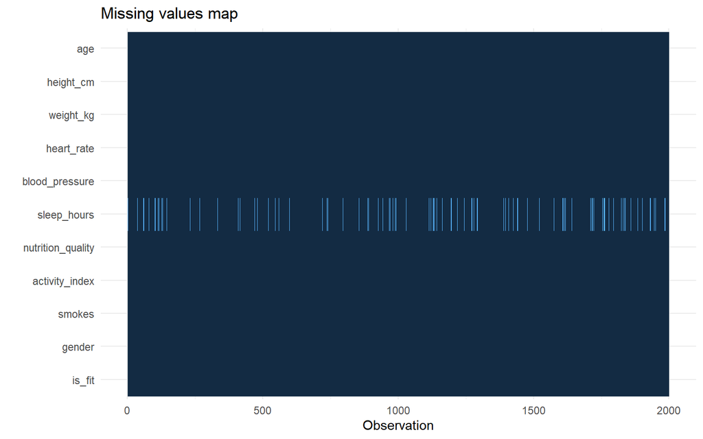

```r
data %>% missing_plot()
```

```r
cat("Total missing values in raw data:", sum(is.na(data)), "\n")
```

```
## Total missing values in raw data: 160
```

```r
colSums(is.na(data))
```

```
##               age         height_cm         weight_kg        heart_rate
##                 0                 0                 0                 0
##    blood_pressure       sleep_hours nutrition_quality    activity_index
##                 0               160                 0                 0
##            smokes            gender            is_fit
##                 0                 0                 0
```

Phew, not much missing data, which is great! Notice how the `sleep_hours` column has approximately 8% missing values (around 160 observations). This is a modest proportion, and since sleep is physiologically meaningful for fitness, we choose to drop these rows rather than impute them—retaining the remaining ~1,840 observations. No other column has meaningful missingness.

The `smokes` column contains mixed data types: the values `1`, `"1"`, and `"yes"` all represent smokers, while `0`, `"0"`, and `"no"` represent non-smokers. This is a data quality issue we address by standardizing to a clean factor.

## Data Cleaning

```r
cleandata <- data %>%
  drop_na() %>%
  mutate(smokes = case_when(
    smokes %in% c("1", "yes")  ~ "yes",
    smokes %in% c("0", "no")   ~ "no",
    TRUE ~ as.character(smokes)
  )) %>%
  mutate(
    smokes   = factor(smokes,   levels = c("yes", "no")),
    gender   = factor(gender,   levels = c("F", "M")),
    is_fit = factor(is_fit, levels = c(0, 1), labels = c("Not Fit", "Fit"))
  )

cat("Dimensions after cleaning:", nrow(cleandata), "rows x", ncol(cleandata), "columns\n")
```

```
## Dimensions after cleaning: 1840 rows x 11 columns
```

```r
cat("Missing values after cleaning:", sum(is.na(cleandata)), "\n")
```

```
## Missing values after cleaning: 0
```

After cleaning, we have 1840 complete, tidy observations ready for analysis. The outcome variable `is_fit` has been re-coded as a factor with levels `Not_Fit` and `Fit`, as required for classification in `tidymodels`. Lets run the map again!

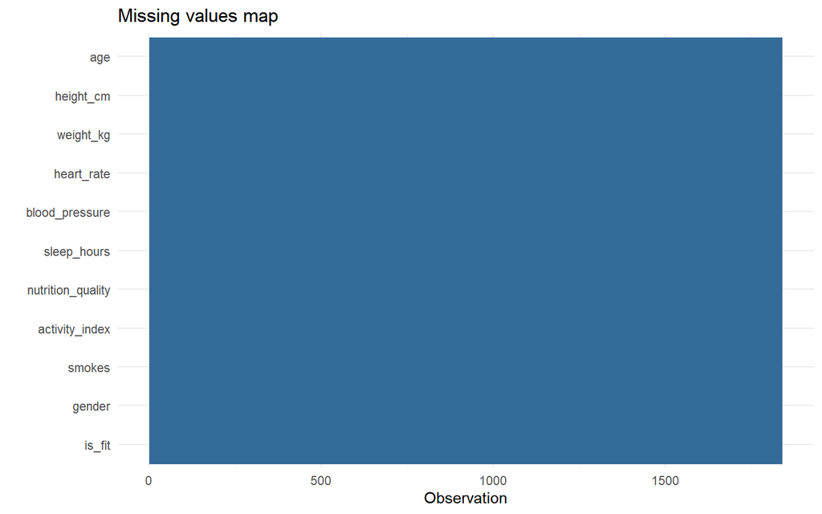

```r
cleandata %>% missing_plot()
```

```r
cleandata %>%
  head(10) %>%
  kable(caption = "First 10 rows of the final fitness dataset") %>%
  kable_styling(bootstrap_options = c("striped", "hover", "condensed"), full_width = FALSE)
```

First 10 rows of the final fitness dataset

| age | height_cm | weight_kg | heart_rate | blood_pressure | sleep_hours | nutrition_quality | activity_index | smokes | gender | is_fit |
| --- | --- | --- | --- | --- | --- | --- | --- | --- | --- | --- |
| 69 | 186 | 95 | 60.8 | 114.8 | 7.5 | 8.77 | 3.19 | no | F | Fit |
| 32 | 189 | 83 | 60.2 | 130.1 | 7.0 | 6.18 | 3.68 | no | M | Fit |
| 60 | 175 | 99 | 58.1 | 115.8 | 8.0 | 9.95 | 4.83 | yes | F | Fit |
| 25 | 172 | 85 | 81.2 | 119.2 | 7.7 | 7.35 | 4.08 | yes | M | Not Fit |
| 78 | 193 | 83 | 79.6 | 132.5 | 7.4 | 2.16 | 3.42 | yes | F | Not Fit |
| 38 | 188 | 57 | 81.2 | 110.6 | 6.6 | 8.47 | 4.96 | no | M | Fit |
| 56 | 164 | 108 | 70.1 | 140.9 | 9.1 | 4.15 | 2.06 | no | F | Not Fit |
| 75 | 198 | 55 | 67.1 | 129.5 | 8.1 | 0.36 | 1.25 | no | F | Not Fit |
| 36 | 153 | 63 | 67.3 | 92.1 | 5.9 | 3.21 | 1.13 | no | M | Not Fit |
| 40 | 178 | 55 | 82.3 | 112.3 | 8.5 | 7.64 | 3.84 | no | M | Fit |

The missing data plot now shows no missing values and smokes and is_fit are all organized. We have cleaned the dataset!

## Codebook Summary

The table below summarizes all variables in the dataset:

```r
codebook <- tibble(
  Variable         = c("age", "height_cm", "weight_kg", "heart_rate", "blood_pressure",
                        "sleep_hours", "nutrition_quality", "activity_index", "smokes", "gender", "is_fit"),
  Type             = c("Integer", "Integer", "Integer", "Float", "Float",
                        "Float", "Float", "Float", "Factor", "Factor", "Factor (Outcome)"),
  Description      = c(
    "Age of the individual in years",
    "Height in centimeters",
    "Weight in kilograms (contains some outliers)",
    "Resting heart rate in beats per minute",
    "Systolic blood pressure in mmHg",
    "Average hours of sleep per night (~8% missing in raw data)",
    "Daily nutrition quality score (0–10 scale)",
    "Physical activity level score (1–5 scale)",
    "Smoking status: 'yes' or 'no'",
    "Gender: 'M' (Male) or 'F' (Female)",
    "1 = Fit, 0 = Not Fit (binary classification outcome)"
  )
)

codebook %>%
  kable(caption = "Codebook: All variables in the Fitness Classification Dataset") %>%
  kable_styling(bootstrap_options = c("striped", "hover"), full_width = TRUE)
```

Codebook: All variables in the Fitness Classification Dataset

| Variable | Type | Description |
| --- | --- | --- |
| age | Integer | Age of the individual in years |
| height_cm | Integer | Height in centimeters |
| weight_kg | Integer | Weight in kilograms (contains some outliers) |
| heart_rate | Float | Resting heart rate in beats per minute |
| blood_pressure | Float | Systolic blood pressure in mmHg |
| sleep_hours | Float | Average hours of sleep per night (~8% missing in raw data) |
| nutrition_quality | Float | Daily nutrition quality score (0–10 scale) |
| activity_index | Float | Physical activity level score (1–5 scale) |
| smokes | Factor | Smoking status: ‘yes’ or ‘no’ |
| gender | Factor | Gender: ‘M’ (Male) or ‘F’ (Female) |
| is_fit | Factor (Outcome) | 1 = Fit, 0 = Not Fit (binary classification outcome) |

## Exploratory Data Analysis (EDA)

With a clean dataset in hand, we now explore the distributions of each variable. We are going to do alot of visualization in this part! Before diving into the features, it’s worth asking how balanced is the dataset we’re working with? A heavily skewed target variable can quietly sabotage a model, so let’s check the class distribution of is_fit first.

```r
cleandata %>%
  count(is_fit) %>%
  mutate(prop = round(n / sum(n), 3)) %>%
  kable(caption = "Class distribution of the outcome variable is_fit") %>%
  kable_styling(bootstrap_options = c("striped", "hover"), full_width = FALSE)
```

Class distribution of the outcome variable is_fit

| is_fit | n | prop |
| --- | --- | --- |
| Not Fit | 1107 | 0.602 |
| Fit | 733 | 0.398 |

Not terrible, but not perfectly balanced either. About 60% of the observations fall under “Not Fit” and 40% are “Fit”, which is a moderate imbalance worth keeping in mind. Let’s also visualize it using a bar graph.

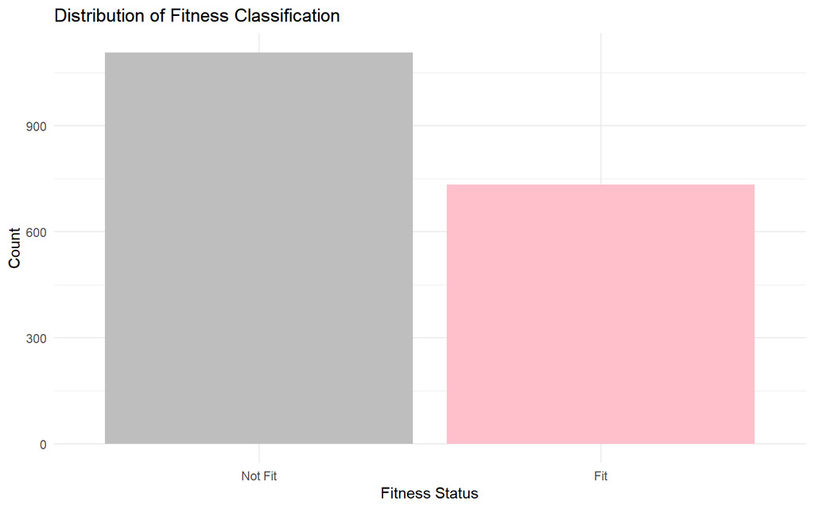

```r
ggplot(cleandata, aes(x = is_fit, fill = is_fit)) +
  geom_bar() +
  scale_fill_manual(values = c("Not Fit" = "grey", "Fit" = "pink")) +
  labs(title = "Distribution of Fitness Classification",
       x = "Fitness Status", y = "Count") +
  theme_minimal() +
  theme(legend.position = "none")
```

### Distribution of Numeric Predictors

Now let’s get a feel for the numeric predictors in the dataset. Before building any model, it’s important to understand the shape of each variable are they normally distributed, skewed, or something else entirely? A quick look at all of them at once gives us a solid starting point.

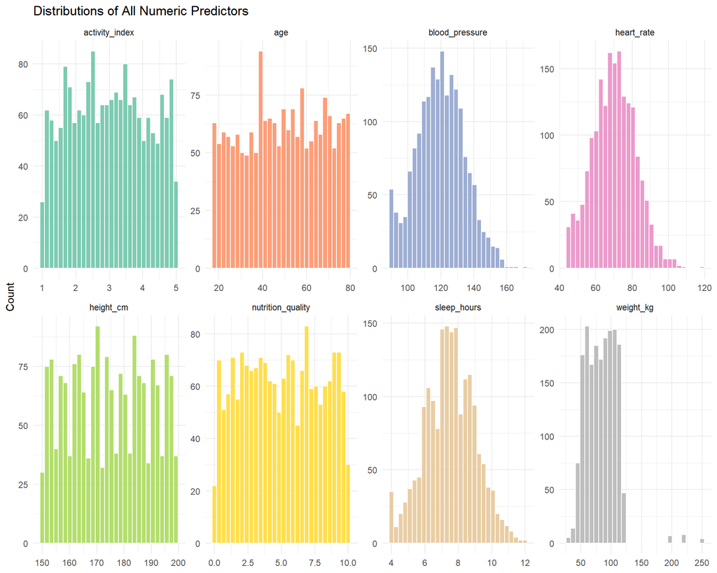

```r
cleandata %>%
  select(age, height_cm, weight_kg, heart_rate, blood_pressure,
         sleep_hours, nutrition_quality, activity_index) %>%
  pivot_longer(everything(), names_to = "variable", values_to = "value") %>%
  ggplot(aes(x = value, fill = variable)) +
  geom_histogram(bins = 30, color = "white", alpha = 0.85) +
  facet_wrap(~variable, scales = "free", ncol = 4) +
  scale_fill_brewer(palette = "Set2") +
  labs(title = "Distributions of All Numeric Predictors", x = NULL, y = "Count") +
  theme_minimal() +
  theme(legend.position = "none")
```

Quite a mixed bag here. blood_pressure and sleep_hours both show a nice bell-shaped curve, which is what I’d hope to see. heart_rate leans slightly right-skewed, and weight_kg has a sharp drop-off on the right with what looks like a few stray outliers way out past 200kg. Age and activity_index are both notably flat and uniform, suggesting they were deliberately spread evenly across their ranges during data generation. height_cm and nutrition_quality also look fairly uniform with no strong central peak. Overall, no extreme skew that demands immediate transformation.

### Numeric Predictors by Fitness Status

Now that we know the shape of our variables, let’s see which ones actually differ between people who are Fit and those who aren’t. Boxplots are perfect for this, they let us compare the spread and median of each numeric predictor side by side across our two target classes.

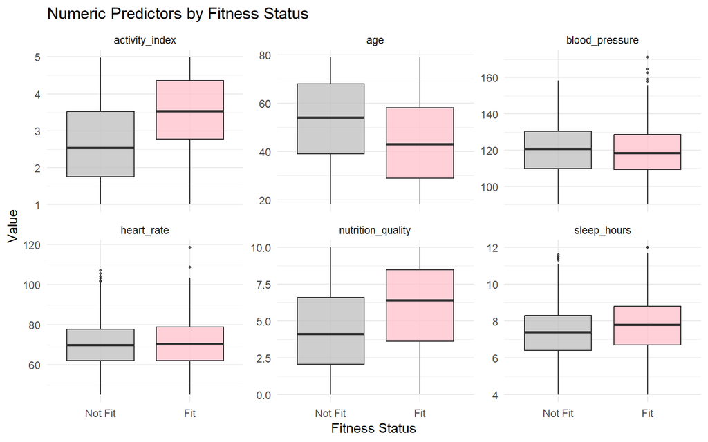

```r
cleandata %>%
  select(is_fit, age, heart_rate, blood_pressure,
         sleep_hours, nutrition_quality, activity_index) %>%
  pivot_longer(-is_fit, names_to = "variable", values_to = "value") %>%
  ggplot(aes(x = is_fit, y = value, fill = is_fit)) +
  geom_boxplot(alpha = 0.75, outlier.size = 0.8) +
  scale_fill_manual(values = c("Not Fit" = "grey", "Fit" = "pink")) +
  facet_wrap(~variable, scales = "free_y", ncol = 3) +
  labs(title = "Numeric Predictors by Fitness Status",
       x = "Fitness Status", y = "Value") +
  theme_minimal() +
  theme(legend.position = "none")
```

### Correlation Matrix

Before moving to the model training phase, it is important to check for high correlation among our numeric predictors. Highly correlated features can introduce multicollinearity, which inflates the variance of coefficient estimates in parametric models like Logistic Regression and can destabilize the covariance matrices in Discriminant Analysis. We can visualize these relationships using a correlation matrix.

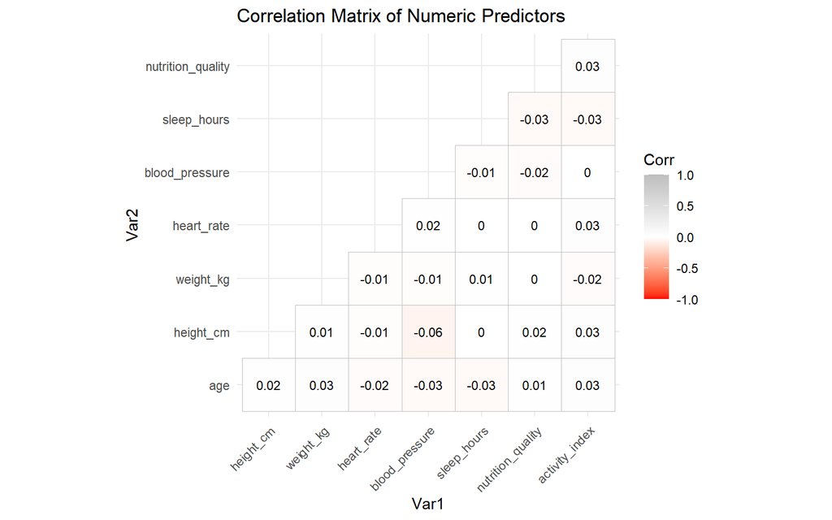

```r
numeric_vars <- cleandata %>%
  select(age, height_cm, weight_kg, heart_rate, blood_pressure,
         sleep_hours, nutrition_quality, activity_index)

cor_matrix <- cor(numeric_vars, use = "complete.obs")

ggcorrplot(cor_matrix,
           method = "square",
           type = "lower",
           lab = TRUE,
           lab_size = 3,
           colors = c("red", "white", "grey"),
           title = "Correlation Matrix of Numeric Predictors") +
  theme_minimal() +
  theme(axis.text.x = element_text(angle = 45, hjust = 1))
```

The correlation matrix reveals that all numeric predictors in this dataset are essentially uncorrelated with one another. Every pairwise coefficient is extremely close to zero, with the largest absolute value being just -0.06 between height_cm and blood_pressure.

This is actually an ideal situation for modelling. High multicollinearity between predictors can inflate standard errors in logistic regression and LDA, making coefficient estimates unstable and harder to interpret. Since no two predictors are strongly correlated here, each variable contributes independently to the model and we don’t need to worry about dropping or combining any of them due to redundancy. It is also worth noting that this is a telltale sign of synthetic data. Real-world health measurements tend to have natural correlations between them, and I would typically expect height and weight to move together for example, but here they don’t. That is just the synthetic generation process treating each feature as independent. That said, the lack of correlation between predictors doesn’t mean the variables are useless. We already saw from the boxplots that several of them separate the two fitness classes quite well. Their predictive power comes from their relationship with the outcome, not with each other, which is exactly what we want going into modelling.

### Categorical Predictors by Fitness Status

Let’s shift from numeric variables to the categorical ones. Rather than looking at distributions, we want to know whether gender and smoking status are associated with fitness outcomes. Stacked proportion bars make this easy to read since both groups are scaled to the same height, so we’re comparing proportions rather than raw counts.

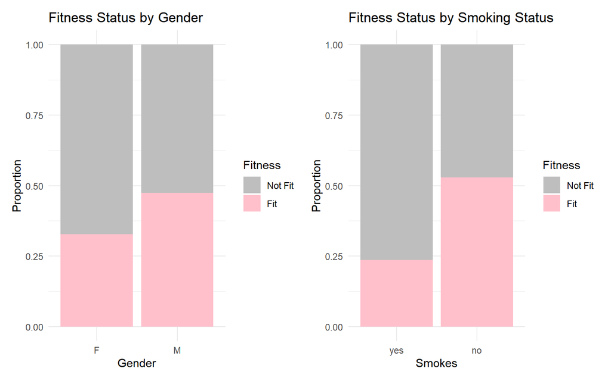

```r
p1 <- ggplot(cleandata, aes(x = gender, fill = is_fit)) +
  geom_bar(position = "fill") +
  scale_fill_manual(values = c("Not Fit" = "grey", "Fit" = "pink")) +
  labs(title = "Fitness Status by Gender",
       x = "Gender", y = "Proportion", fill = "Fitness") +
  theme_minimal()

p2 <- ggplot(cleandata, aes(x = smokes, fill = is_fit)) +
  geom_bar(position = "fill") +
  scale_fill_manual(values = c("Not Fit" = "grey", "Fit" = "pink")) +
  labs(title = "Fitness Status by Smoking Status",
       x = "Smokes", y = "Proportion", fill = "Fitness") +
  theme_minimal()

p1 + p2
```

Looking at the two categorical predictors, we can draw some interesting observations. For gender, males appear to have a higher proportion of fit individuals compared to females, roughly 50% of males are classified as fit versus only about 33% of females. This suggests gender may play a modest role in fitness classification, though since the data are synthetic, we should be cautious about over-interpreting this difference.

### Sleep Hours

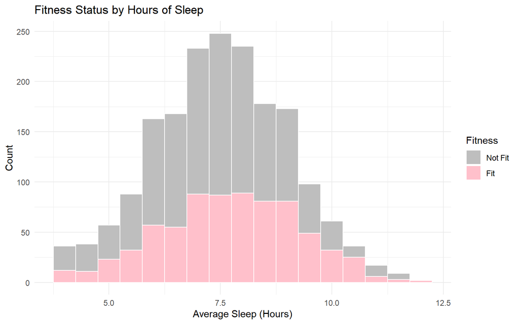

```r
ggplot(cleandata, aes(x = sleep_hours, fill = is_fit)) +
  geom_histogram(binwidth = 0.5, position = "stack", color = "white") +
  scale_fill_manual(values = c("Not Fit" = "grey", "Fit" = "pink")) +
  labs(title = "Fitness Status by Hours of Sleep",
       x = "Average Sleep (Hours)",
       y = "Count",
       fill = "Fitness") +
  theme_minimal()
```

### Nutrition Quality

You can’t out-train a bad diet. Nutrition quality (measured on a 1-10 scale) should theoretically have a strong positive relationship with overall fitness. The plot below confirms this expectation. The density of “Fit” individuals increases toward the higher end of the nutrition scale, while “Not Fit” individuals are more dominant at lower scores.

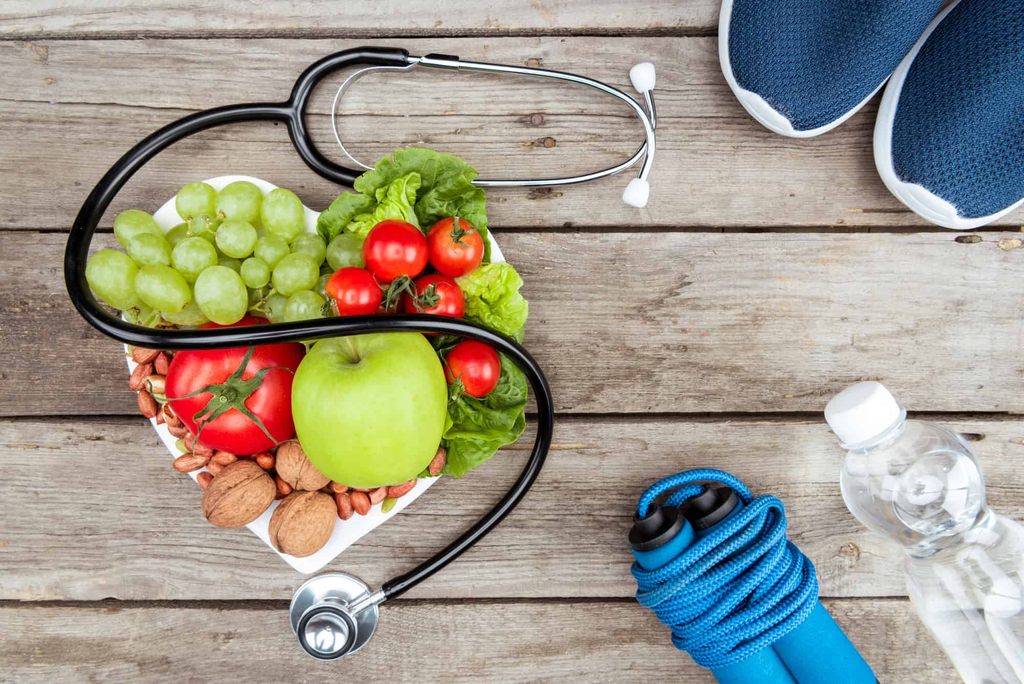

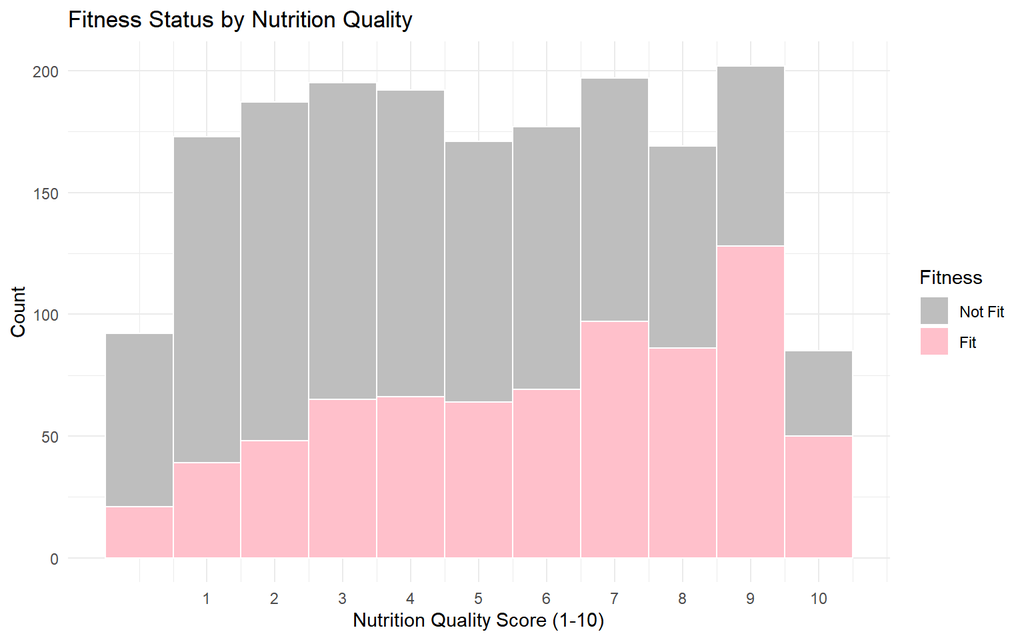

```r
ggplot(cleandata, aes(x = nutrition_quality, fill = is_fit)) +
  geom_histogram(binwidth = 1, position = "stack", color = "white") +
  scale_fill_manual(values = c("Not Fit" = "grey", "Fit" = "pink")) +
  labs(title = "Fitness Status by Nutrition Quality",
       x = "Nutrition Quality Score (1-10)",
       y = "Count",
       fill = "Fitness") +
  scale_x_continuous(breaks = 1:10) +
  theme_minimal()
```

It’s time to start eating healthly! As we can see in the graph, the high nutrition quality score, the fit you are!

### Physical Activity Index

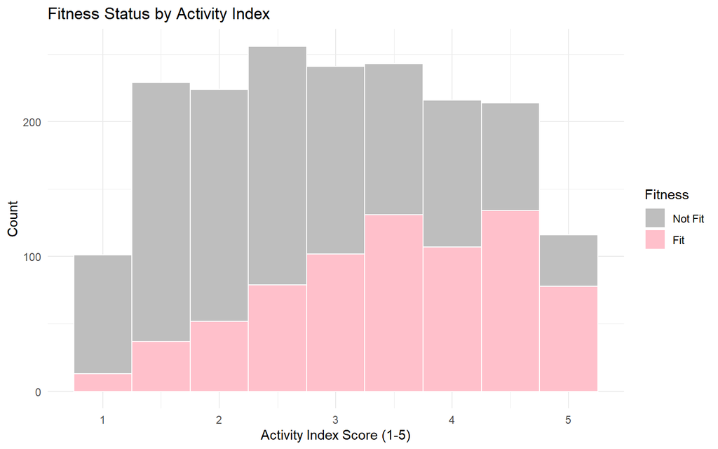

```r
ggplot(cleandata, aes(x = activity_index, fill = is_fit)) +
  geom_histogram(binwidth = 0.5, position = "stack", color = "white") +
  scale_fill_manual(values = c("Not Fit" = "grey", "Fit" = "pink")) +
  labs(title = "Fitness Status by Activity Index",
       x = "Activity Index Score (1-5)",
       y = "Count",
       fill = "Fitness") +
  theme_minimal()
```

This is the same outcome as nutrition quality score, the more you exercise, the healthier you become.

# Setting Up Models

With the EDA complete, we now have a solid understanding of our data. We know which features show the strongest separation between fitness classes, we have confirmed there is no multicollinearity to worry about, and we have a modest class imbalance to keep in mind. Now it is time to put that knowledge to work and build our models.

The setup follows a standard supervised learning pipeline. We split the data into training and testing sets, define a shared preprocessing recipe, and set up cross-validation before fitting any models. This structure ensures that every model is evaluated fairly and that our final performance estimates reflect how well each model generalizes to data it has never seen before.

## Train/Test Split

Before we can begin fitting any models, we must first divide our cleaned dataset into a training set and a testing set. The training set is what our models will learn from, while the testing set is held out entirely and will only be used at the very end to evaluate the performance of our best models. Keeping this separation strict is essential, evaluating on data the model has already seen would give us an overly optimistic picture of how well it generalizes to new observations. We split the data into 80% training and 20% testing, using stratified sampling on is_fit to ensure that the proportion of fit and not fit individuals is preserved in both sets.

```r
set.seed(231)
fit_split <- initial_split(cleandata, prop = 0.80, strata = is_fit)
fit_train <- training(fit_split)
fit_test  <- testing(fit_split)

cat("Training set:", nrow(fit_train), "observations\n")
```

```
## Training set: 1471 observations
```

```r
cat("Testing set: ", nrow(fit_test),  "observations\n")
```

```
## Testing set:  369 observations
```

## Preprocessing Recipe

Now that our data is clean and we understand what we are working with, it is time to build our recipe. Think of it like prepping your ingredients before cooking a meal. You would not just throw raw, unpeeled vegetables into a pot and hope for the best, you wash them, chop them, and get everything ready before the heat goes on. That is exactly what we are doing here. We have two categorical variables, gender and smokes, that need to be dummy encoded so our models can read them as numbers rather than labels. Then we center and scale all the numeric predictors so everything is on the same playing field. Imagine trying to compare someone’s height in centimeters to their nutrition score out of 10 without scaling, the model might incorrectly treat the larger numbers as more important just because they are bigger. Not every model strictly needs this treatment. Random forest and boosted trees would be perfectly happy without it. But since logistic regression, LDA, QDA, and elastic net do need it, we apply one single recipe to all of our models and keep things clean and consistent.

```r
fit_recipe <- recipe(is_fit ~ ., data = fit_train) %>%
  step_dummy(all_nominal_predictors()) %>%
  step_normalize(all_numeric_predictors())
```

## K-Fold Cross Validation

Now that we have our recipe ready, we need a reliable way to evaluate how well each model is actually learning versus just memorizing the training data. This is where cross-validation comes in. Think of it like studying for an exam with practice tests. Instead of reviewing your notes once and hoping for the best, you test yourself repeatedly on different subsets of the material to make sure you actually understand it. That is exactly what 10-fold cross-validation does. The training data gets split into 10 equal chunks. Each model trains on 9 of those chunks and gets tested on the one it has not seen, rotating through all 10 combinations. By the end, we have 10 separate performance estimates that we average together for a much more honest picture of how each model generalizes. We stratify the folds on is_fit to make sure each fold has the same class balance as the full training set, we would not want one fold to accidentally end up with almost no “Fit” individuals, for example. Our main evaluation metric throughout will be ROC AUC, which measures how well a model separates the two classes across all possible decision thresholds. It gives us a more complete picture of model performance than accuracy alone, especially when we care about overall discrimination rather than just getting the majority class right.

```r
set.seed(231)
fit_folds <- vfold_cv(fit_train, v = 10, strata = is_fit)
```

```r
save(fit_folds, fit_recipe, fit_train, fit_test,
     file = "C:/Users/qiuso/OneDrive/131/RDA/fitness_Model_Setup.rda")
```

# Building Models

With our recipe built and our cross-validation folds ready, we have finally reached the part we have been working toward. Everything up to this point (the cleaning, the EDA, the preprocessing) was just preparation. Now we actually build the models.

Since we are predicting a binary outcome, fit or not fit, we need classification algorithms. Rather than committing to just one, I decided to test seven different approaches. Starting simple and working up to more complex methods gives us a clearer picture of how much that added complexity is actually buying us.

## Selecting the Right Models

- **Logistic Regression:** The natural starting point for any binary classification problem. Simple, interpretable, and a solid baseline.
- **Linear Discriminant Analysis (LDA):** Finds a linear combination of predictors that best separates the two fitness classes.
- **Quadratic Discriminant Analysis (QDA):** A more flexible version of LDA that relaxes the assumption of equal variance across classes.
- **Elastic Net:** A penalized regression that performs variable selection and guards against overfitting by shrinking less useful coefficients.
- **Decision Tree:** Produces an interpretable flowchart of decisions that lead to a fitness classification.
- **Random Forest:** An ensemble of many decision trees that tends to be highly accurate on structured data.
- **Boosted Tree:** Builds trees sequentially, with each one correcting the mistakes of the last.

## The Model Building Workflow

For every model, I followed the same consistent workflow to make sure comparisons between them are fair.

1. Define the model specification, setting the engine and classification mode.
2. Bundle the model with our shared preprocessing recipe into a workflow.
3. For models with hyperparameters, set up a tuning grid with reasonable ranges and tune across the 10-fold cross-validation folds.
4. Select the best hyperparameter combination and finalize the workflow.
5. Fit the finalized model on the full training set and save the results to an RDA file.

Logistic Regression, LDA, and QDA have no hyperparameters to tune, so they skip straight from step 2 to step 5.

# Model Results

The models took 20 mins to run, the random forest and boosted tree in particular were not in any rush. But now that everything has finished, the results are saved and ready to load. Let’s see which algorithm did the best job of learning what it actually means to be fit.

```r
load("C:/Users/qiuso/OneDrive/131/RDA/fitness_Model_Setup.rda")
load("C:/Users/qiuso/OneDrive/131/RDA/fitness_Logistic_Regression.rda")
load("C:/Users/qiuso/OneDrive/131/RDA/fitness_Linear_Discriminant.rda")
load("C:/Users/qiuso/OneDrive/131/RDA/fitness_Quadratic_Discriminant.rda")
load("C:/Users/qiuso/OneDrive/131/RDA/fitness_Elastic_Net.rda")
load("C:/Users/qiuso/OneDrive/131/RDA/fitness_Decision_Tree.rda")
load("C:/Users/qiuso/OneDrive/131/RDA/fitness_Random_Forest.rda")
load("C:/Users/qiuso/OneDrive/131/RDA/fitness_Boosted_Tree.rda")
```

## Visualizing Tuning Results

One of the most useful tools for visualizing the results of models that have been tuned is the `autoplot()` function. This will visualize the effects that changing certain hyperparameters has on our primary metric, ROC AUC. We will display the tuning plots for all four tunable models.

### Elastic Net

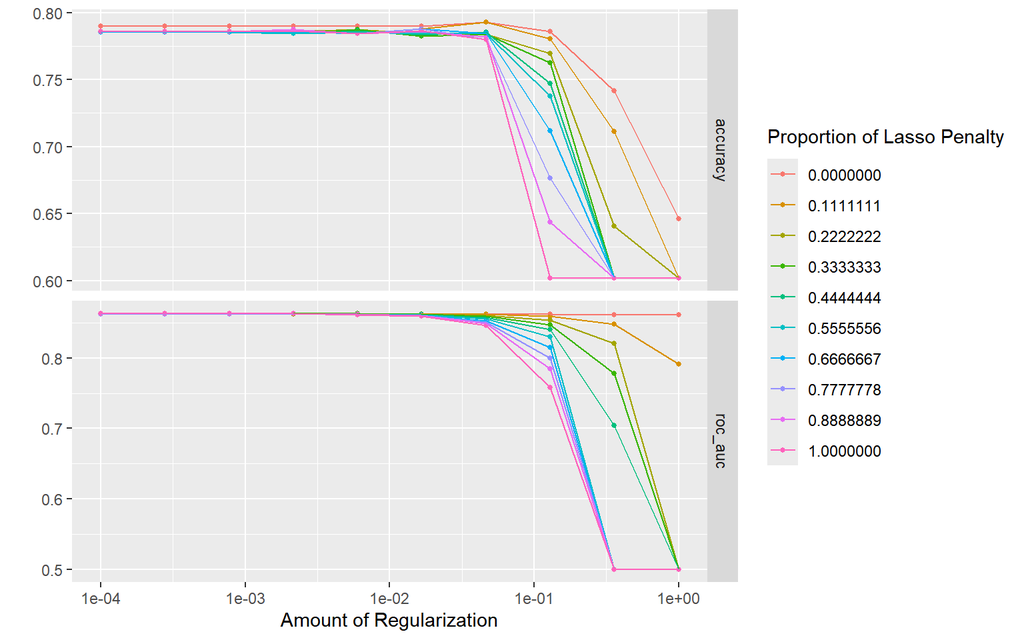

```r
autoplot(en_res)
```

The tuning plot shows how accuracy and ROC AUC change as we adjust the amount of regularization and the proportion of lasso penalty. The most important thing to notice is that all the lines stay flat and close together on the left side of the plot, meaning performance is stable across a wide range of penalty values. It is only when the regularization gets very aggressive, around the 0.1 mark and beyond, that performance starts to drop off sharply. What this tells us is that the model actually needs most of its predictors to perform well. Elastic net works by shrinking or removing less useful variables, so if only a few predictors mattered, the model would handle heavy penalization just fine. The fact that it falls apart when too many variables get pushed out suggests that most of them are contributing something meaningful, which lines up perfectly with what we saw in the EDA.

### Decision Tree

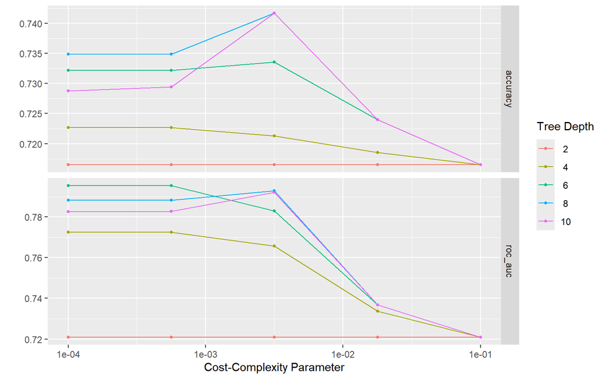

```r
autoplot(tree_res)
```

### Random Forest

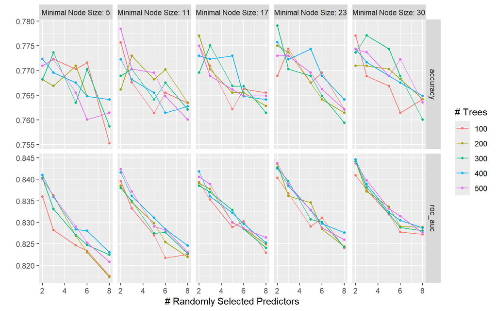

```r
autoplot(rf_res)
```

The random forest tuning plot is busier than the others since we are tuning three hyperparameters at once: the number of randomly selected predictors, the minimal node size, and the number of trees. Each panel represents a different minimal node size, and the lines within each panel represent different numbers of trees. The clearest pattern here is that ROC AUC consistently drops as the number of randomly selected predictors increases. This makes sense for our dataset. Remember from the EDA that most of our predictors carry independent and useful signal. When the model is forced to consider too many predictors at each split, the trees become more similar to each other and the forest loses the diversity that makes it powerful in the first place. The number of trees and minimal node size do not seem to make a dramatic difference. The lines for 100 up to 500 trees are fairly close together across all panels, which tells us the model is not very sensitive to those settings within the ranges we tested. The best performance lands around 0.84 to 0.85 ROC AUC, which is solid but not dramatically better than what the simpler linear models already achieved. This is actually telling us something important about the data. Since random forest thrives on complex interactions and non-linear patterns, the fact that it is not pulling ahead suggests the relationships in this dataset are mostly clean and straightforward, which makes sense given that it is synthetic.

### Boosted Tree

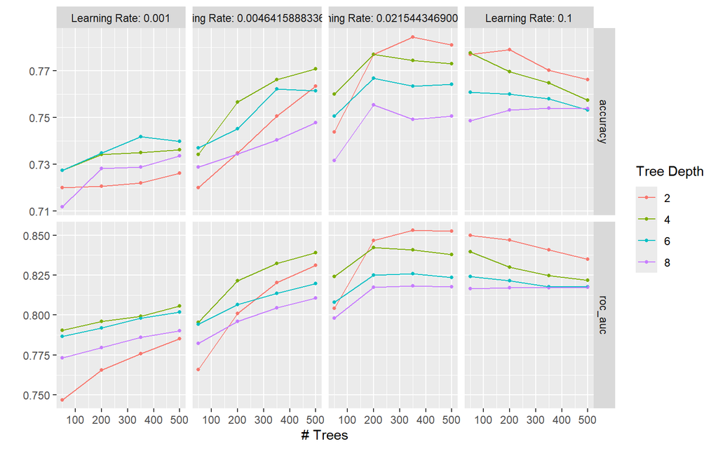

```r
autoplot(xgb_res)
```

## Model Accuracies

Now that we have explored how each model was tuned, we can summarize their best cross-validated ROC AUC scores in a single table. For the non-tuned models (logistic regression, LDA, QDA), we collect the mean ROC AUC across folds directly. For the tuned models, we extract the best configuration found during the tuning process.

```r
all_cv_results <- bind_rows(
  collect_metrics(log_res) %>% mutate(model = "Logistic Regression"),
  collect_metrics(lda_res) %>% mutate(model = "LDA"),
  collect_metrics(qda_res) %>% mutate(model = "QDA"),
  show_best(en_res,   metric = "roc_auc", n = 1) %>% mutate(model = "Elastic Net"),
  show_best(tree_res, metric = "roc_auc", n = 1) %>% mutate(model = "Decision Tree"),
  show_best(rf_res,   metric = "roc_auc", n = 1) %>% mutate(model = "Random Forest"),
  show_best(xgb_res,  metric = "roc_auc", n = 1) %>% mutate(model = "Boosted Tree")
) %>%
  filter(.metric == "roc_auc") %>%
  select(Model = model, `CV ROC AUC` = mean) %>%
  arrange(desc(`CV ROC AUC`))

all_cv_results %>%
  kable(caption = "Cross-Validated ROC AUC for All Seven Models", digits = 4) %>%
  kable_styling(bootstrap_options = c("striped", "hover", "condensed"),
                full_width = FALSE)
```

Cross-Validated ROC AUC for All Seven Models

| Model | CV ROC AUC |
| --- | --- |
| Elastic Net | 0.8626 |
| Logistic Regression | 0.8622 |
| LDA | 0.8622 |
| QDA | 0.8622 |
| Boosted Tree | 0.8530 |
| Random Forest | 0.8446 |
| Decision Tree | 0.7953 |

As we can see in our table , the Elastic Net model performed the best overall, closely followed by the simpler parametric models (Logistic Regression, LDA, and QDA). Surprisingly, the ensemble methods (Random Forest and Boosted Tree) performed worse than the linear models, and the decision tree performed the poorest.

Wait…why did the more complex models not do better? To find out, it helps to look at how well each model performed on the data it was actually trained on.

```r
fit_log_reg_auc <- augment(log_fit, new_data = fit_train) %>%
  roc_auc(is_fit, .pred_Fit, event_level = "second") %>%
  select(.estimate)

fit_lda_auc <- augment(lda_fit, new_data = fit_train) %>%
  roc_auc(is_fit, .pred_Fit, event_level = "second") %>%
  select(.estimate)

fit_qda_auc <- augment(qda_fit, new_data = fit_train) %>%
  roc_auc(is_fit, .pred_Fit, event_level = "second") %>%
  select(.estimate)

fit_en_auc <- augment(en_final_fit, new_data = fit_train) %>%
  roc_auc(is_fit, .pred_Fit, event_level = "second") %>%
  select(.estimate)

fit_decision_tree_auc <- augment(tree_final_fit, new_data = fit_train) %>%
  roc_auc(is_fit, .pred_Fit, event_level = "second") %>%
  select(.estimate)

fit_random_forest_auc <- augment(final_rf_fit, new_data = fit_train) %>%
  roc_auc(is_fit, .pred_Fit, event_level = "second") %>%
  select(.estimate)

fit_xgb_auc <- augment(final_xgb_fit, new_data = fit_train) %>%
  roc_auc(is_fit, .pred_Fit, event_level = "second") %>%
  select(.estimate)

fit_roc_aucs <- c(fit_log_reg_auc$.estimate,
                  fit_lda_auc$.estimate,
                  fit_qda_auc$.estimate,
                  fit_en_auc$.estimate,
                  fit_decision_tree_auc$.estimate,
                  fit_random_forest_auc$.estimate,
                  fit_xgb_auc$.estimate)

fit_mod_names <- c("Logistic Regression",
                   "LDA",
                   "QDA",
                   "Elastic Net",
                   "Decision Tree",
                   "Random Forest",
                   "Boosted Tree")

tibble(Model = fit_mod_names, `Training ROC AUC` = fit_roc_aucs) %>%
  arrange(desc(`Training ROC AUC`)) %>%
  kable(caption = "ROC AUC", digits = 4) %>%
  kable_styling(bootstrap_options = c("striped", "hover", "condensed"), full_width = FALSE)
```

ROC AUC

| Model | Training ROC AUC |
| --- | --- |
| Random Forest | 0.9757 |
| Boosted Tree | 0.8862 |
| QDA | 0.8673 |
| Decision Tree | 0.8605 |
| Logistic Regression | 0.8543 |
| LDA | 0.8543 |
| Elastic Net | 0.8543 |

### Comparing table

To select the final model, I compared the Training ROC AUC against the Cross-Validated (CV) ROC AUC. This comparison is important because it reveals the Bias-Variance Tradeoff. A model that performs perfectly on training data but poorly on CV data is “overfitting”.

```r
training_auc_results <- tibble(
  Model = c(
    "Logistic Regression",
    "LDA",
    "QDA",
    "Elastic Net",
    "Decision Tree",
    "Random Forest",
    "Boosted Tree"
  ),
  `Training ROC AUC` = c(
    fit_log_reg_auc,
    fit_lda_auc,
    fit_qda_auc,
    fit_en_auc,
    fit_decision_tree_auc,
    fit_random_forest_auc,
    fit_xgb_auc
  )
)

comparison_table <- full_join(
  all_cv_results,
  training_auc_results,
  by = "Model"
) %>%
  mutate(
    `CV ROC AUC` = as.numeric(`CV ROC AUC`),
    `Training ROC AUC` = as.numeric(`Training ROC AUC`),
    `Gap (Train - CV)` = `Training ROC AUC` - `CV ROC AUC`
  ) %>%
  arrange(desc(`CV ROC AUC`))

comparison_table %>%
  kable(
    caption = "Training vs Cross-Validated ROC AUC Comparison",
    digits = 4
  ) %>%
  kable_styling(
    bootstrap_options = c("striped", "hover", "condensed"),
    full_width = FALSE
  )
```

Training vs Cross-Validated ROC AUC Comparison

| Model | CV ROC AUC | Training ROC AUC | Gap (Train - CV) |
| --- | --- | --- | --- |
| Elastic Net | 0.8626 | 0.8543 | -0.0084 |
| Logistic Regression | 0.8622 | 0.8543 | -0.0079 |
| LDA | 0.8622 | 0.8543 | -0.0079 |
| QDA | 0.8622 | 0.8673 | 0.0051 |
| Boosted Tree | 0.8530 | 0.8862 | 0.0332 |
| Random Forest | 0.8446 | 0.9757 | 0.1311 |
| Decision Tree | 0.7953 | 0.8605 | 0.0651 |

The table tells a very clear story. For training, Random forest sits at the top with a striking 0.9757, which sounds impressive until I remember that its cross-validated ROC AUC was only around 0.84. That gap of roughly 13 percentage points is a textbook case of overfitting. The model essentially memorized the training data and struggled to apply what it learned to new observations.

The boosted tree shows a smaller but still noticeable gap, suggesting it also picked up some noise from the training set along the way.

This is ultimately why **elastic net** was selected as the final model. It was not the flashiest performer on the training data, but it was the most honest one and the best one in Cross-Validated ROC AUC. Great work :)

# Results From Our Best Model

Now that we know which models performed best, we finalize them using their optimal hyperparameters and refit each on the entire training set. They are then evaluated on the held-out test set, data that neither model has seen at any point during training or tuning. Keeping this separation strict is essential for getting an honest picture of how well our models generalize to new observations.

## Final ROC AUC Result

```r
final_en_wf  <- finalize_workflow(en_wf,  best_en)
final_en_fit <- fit(final_en_wf,  data = fit_train)

en_test_preds <- augment(final_en_fit, new_data = fit_test)

en_test_roc_auc <- augment(final_en_fit, new_data = fit_test, type = 'prob') %>%
  roc_auc(is_fit, .pred_Fit, event_level = "second") %>%
  select(.estimate)

en_test_roc_auc
```

```
## # A tibble: 1 × 1
##   .estimate
##       <dbl>
## 1     0.910
```

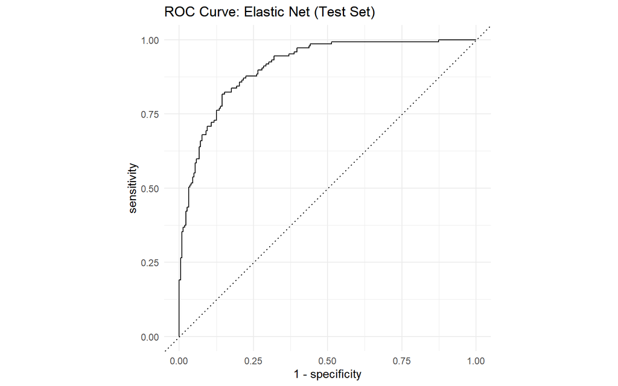

```r
en_test_preds %>%
  roc_curve(truth = is_fit, .pred_Fit, event_level = "second") %>%
  autoplot() +
  labs(title = "ROC Curve: Elastic Net (Test Set)") +
  theme_minimal()
```

The ROC curve gives us a visual confirmation of what the AUC score already told us. The curve hugs the top left corner of the plot quite tightly, which is exactly what I want to see. A perfect classifier would go straight up the left edge and across the top, while a useless one would follow the diagonal dotted line. Our elastic net is clearly much closer to the former. The steep initial climb on the left side of the curve is particularly encouraging. It means that at high confidence thresholds, when the model is most certain about its predictions, it is catching a large proportion of the truly fit individuals while making very few false positive errors. The model is not just getting lucky, it genuinely knows what a fit person looks like. I did a great job of choosing the best model!

### The Best Elastic Net is…

```r
show_best(en_res, metric = "roc_auc") %>%
  select(-.estimator, .config) %>%
  slice(1) %>%
  kable(caption = "Best Elastic Net Hyperparameters", digits = 4) %>%
  kable_styling(bootstrap_options = c("striped", "hover"), full_width = FALSE)
```

Best Elastic Net Hyperparameters

| penalty | mixture | .metric | mean | n | std_err | .config |
| --- | --- | --- | --- | --- | --- | --- |
| 0.0022 | 0.6667 | roc_auc | 0.8626 | 10 | 0.0107 | Preprocessor1_Model064 |

Model 64! After searching through all the hyperparameter combinations, our tuning process identified Elastic Net Model #64 as the optimal configuration. The best model used a penalty of 0.0022 and a mixture of 0.6667. The relatively high mixture value tells us the model found its footing closer to lasso territory, actively zeroing out weaker predictors rather than just shrinking them. This helped the model focus its attention on the variables that actually matter for fitness classification while ignoring the noise.

## Variable Importance

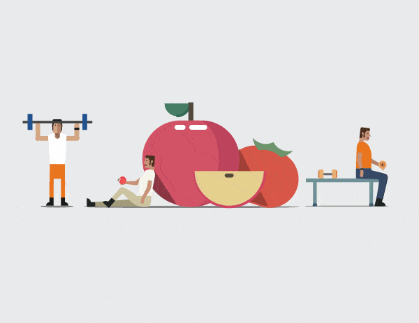

Understanding *which* features drive our predictions is just as important as the predictions themselves.

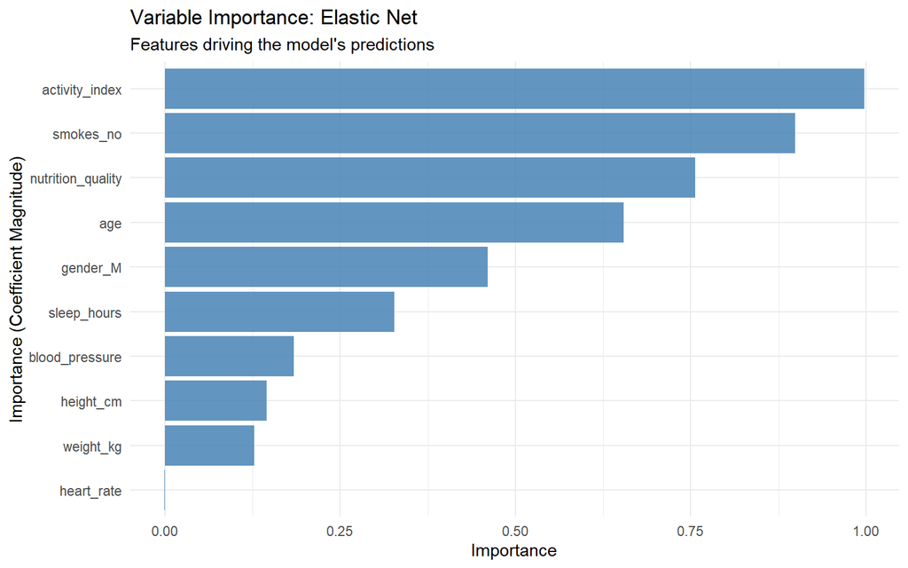

```r
final_en_fit %>%
  extract_fit_parsnip() %>%
  vip(num_features = 10,
      geom = "col",
      aesthetics = list(fill = "steelblue", alpha = 0.85)) +
  labs(title = "Variable Importance: Elastic Net",
       subtitle = "Features driving the model's predictions",
       x = "Importance (Coefficient Magnitude)") +
  theme_minimal()
```

## Putting the Model to the Test

### Fit Individual

Let’s try someone who exercises frequently, eats well, sleeps a healthy amount, and does not smoke, which is exactly the profile we would expect to be classified as fit.

```r
fit_example <- data.frame(
  age               = 25,
  height_cm         = 175,
  weight_kg         = 72,
  heart_rate        = 61.0,
  blood_pressure    = 114.0,
  sleep_hours       = 8.5,
  nutrition_quality = 8.8,
  activity_index    = 4.9,
  smokes            = factor("no",  levels = c("yes", "no")),
  gender            = factor("M",   levels = c("F", "M"))
)

predict(final_en_fit, fit_example, type = "class")
```

```
## # A tibble: 1 × 1
##   .pred_class
##   <fct>
## 1 Fit
```

Our model correctly predicted this individual as **Fit**. This is very encouraging and confirms that the model is picking up on the right signals! High activity, good nutrition, adequate sleep, and non-smoking status all point strongly toward a fit classification.

### Not Fit Individual

Now let’s test the opposite profile, someone sedentary, with a poor diet, low sleep, and a smoking habit and see if the model correctly labels.

```r
fit_example <- data.frame(
  age               = 60,
  height_cm         = 170,
  weight_kg         = 80,
  heart_rate        = 76.0,
  blood_pressure    = 120.0,
  sleep_hours       = 4.5,
  nutrition_quality = 4.3,
  activity_index    = 1.2,
  smokes            = factor("yes",  levels = c("yes", "no")),
  gender            = factor("M",   levels = c("F", "M"))
)

predict(final_en_fit, fit_example, type = "class")
```

```
## # A tibble: 1 × 1
##   .pred_class
##   <fct>
## 1 Not Fit
```

Nice! This is also want I already expected. The model correctly classified this individual as Not Fit. The model had no trouble with this one.

## Final Model Accuracy

While ROC AUC was our primary metric throughout this project, accuracy gives us a simpler and more intuitive way to summarize how well the model performed. The Elastic Net accuracy:

```r
test_predictions <- augment(final_en_fit, new_data = fit_test)

test_predictions %>%
  accuracy(truth = is_fit, estimate = .pred_class)
```

```
## # A tibble: 1 × 3
##   .metric  .estimator .estimate
##   <chr>    <chr>          <dbl>
## 1 accuracy binary         0.824
```

Our elastic net correctly classified about 82.4% of individuals in the test set as either Fit or Not Fit. That means out of every 10 people the model had never seen before, it got roughly 8 of them right. Not bad at all!

# Conclusion

As for where this could go next, the most exciting step would be testing this kind of framework on real world health data instead of synthetic data. Real observations are messier, noisier, and full of the complex interactions that synthetic data tends to smooth over, and that is exactly the environment where more powerful models like random forest and boosted trees would finally have something meaningful to contribute. Adding richer behavioral features like stress levels, sleep quality, or data from wearable devices could also push performance further and bring the model closer to something genuinely useful in a real health or wellness setting.

On a personal note, there is something satisfying about building a model around a topic this relatable. We all kind of already know the answer. Move more, eat better, sleep enough, do not smoke. The model just put numbers to what common sense already tells us, and getting a 91% ROC AUC out of that feels like a pretty good reward for listening to advice we probably already knew.